# Bikesharing for Everyone!

## by Khaled Basiony

## Investigation Overview

> In this investigation I will look primarily at some features in the data, to check if there is anything that affects the durations of the travels and have a better understanding of the users' categories and distribution.

## Dataset Overview

> This dataset consists of roughly 170K records after cleaning, with around 18 columns. I will investigate here some of these columns which are: duration, age, station locations and names, and finally bike IDs (assuming that higher IDs mean better, newer and more expensive bikes).

## Age Distribution

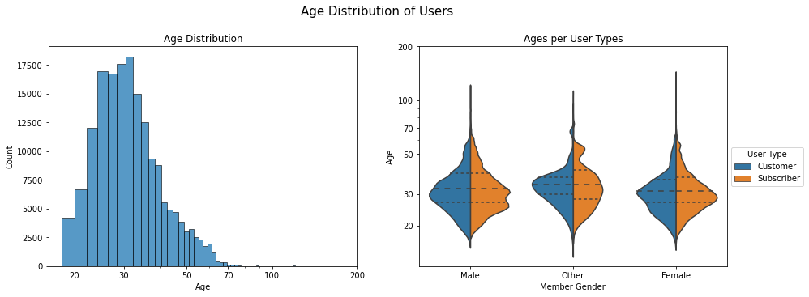

## Most Common Station

> here I have calculated the most common start and end stations, but keep in mind that each one is calculated seperately, so the top one of each, does NOT mean it is the most common route, as a matter of fact it is the 10th common route.

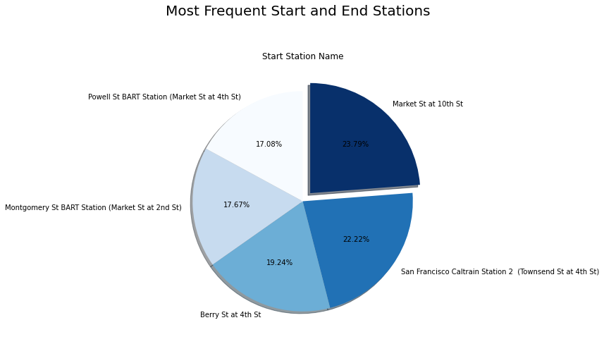

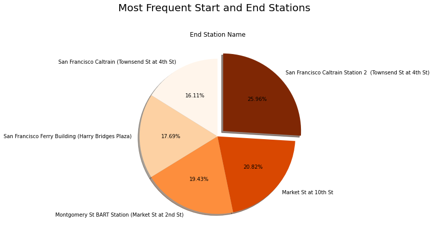

## Durations

> Now it's time to look at the durations, you can fairly say that the durations mostly fall under 20 mins, but mostly it's peaking at around 10 mins.

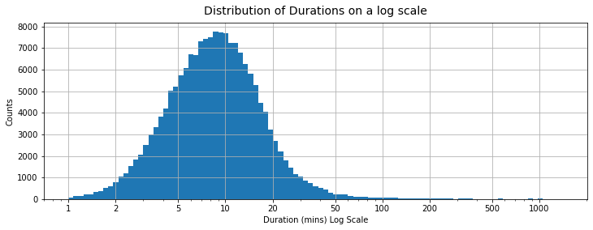

## Time Series

> Here I have Truncated the start time to have the counts of each: hour of the day, day of the week, and day of the month. now keep in mind that truncating means removing all other values, so for example 8:45 is counted as 8 not 9.  
> Now after checking the graphs, you'd see that the counts are consistent with a regular 9 to 5 job, this could mean that the majority of users use the programme to get from home to work and vice versa!

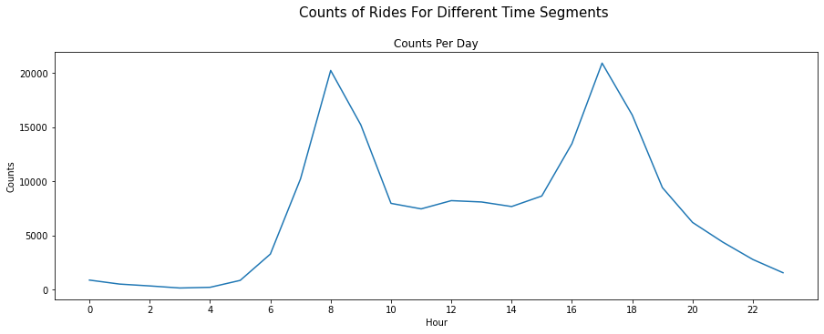

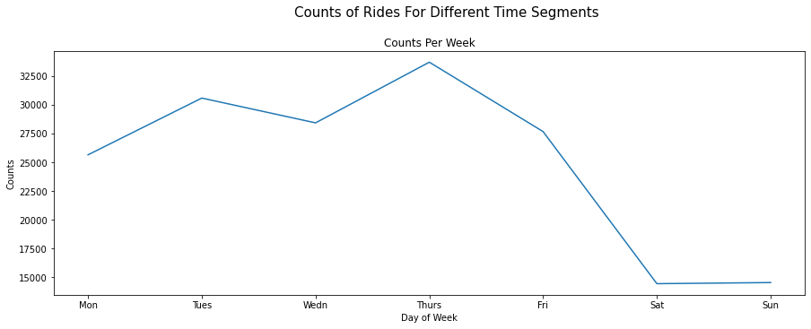

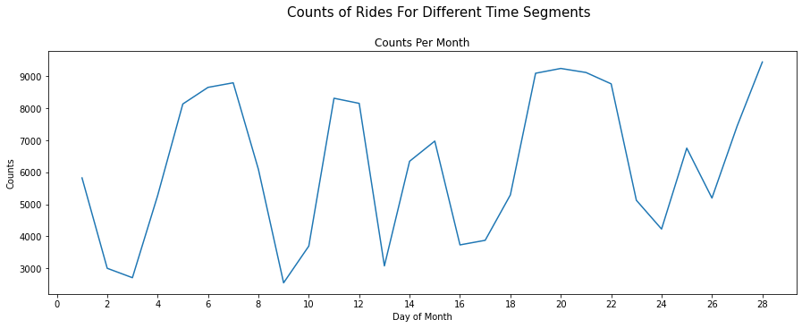

## Locations

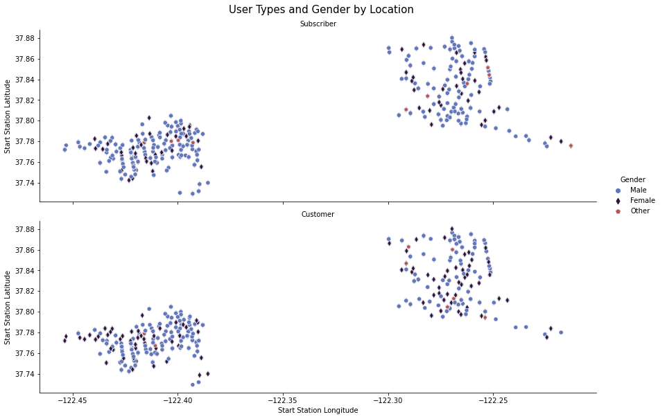

## Age vs Durations

> Now finally We've come to the end of this, with a look at the durations varying with the ages of different types of users, we can see here that the male subscribers are more uniformly distributed on both the age axis and the duration axis, and all the other types of users tend to have a duration closer to 10 mins as they get older.

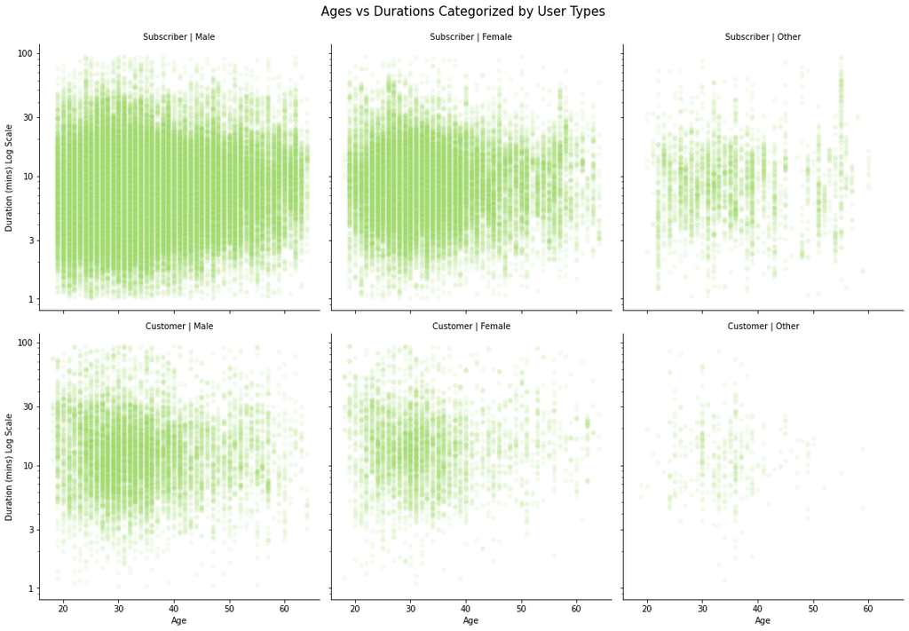